# Tugas Pertemuan 3

Yasmin Azimah

2023-09-16

## Library

```r
library(dLagM)
library(dynlm)
library(MLmetrics)
library(lmtest)
library(car)
```

## Importing Data

```r
data <- rio::import("https://raw.githubusercontent.com/yasminazimah/MPDW/main/Praktikum-3/Data.csv")
Yt = data$AQI
Xt = data$CO
data <- data.frame(Yt,Xt)
str(data)
```

```
## 'data.frame':    72 obs. of  2 variables:
##  $ Yt: num  30.2 28.2 26.6 25 26 26 26 24 23 24 ...
##  $ Xt: num  199 198 199 202 205 ...
```

```r
data
```

```
##      Yt       Xt
## 1  30.2 198.6027
## 2  28.2 197.6013
## 3  26.6 198.6027
## 4  25.0 201.9405
## 5  26.0 205.2784
## 6  26.0 208.6163
## 7  26.0 208.6163
## 8  24.0 205.2784
## 9  23.0 200.2716
## 10 24.0 196.9338
## 11 25.0 198.6027
## 12 26.0 200.2716
## 13 27.0 203.6095
## 14 29.0 205.2784
```

[output cut: 58 more lines]

## Pembagian Data menjadi data training dan data testing

```r
train<-data[1:57,] # 80%
test<-data[58:72,] # 20%
```

## Data time series

```r
train.ts<-ts(train)
test.ts<-ts(test)
data.ts<-ts(data)
```

# Model Koyck

Model Koyck didasarkan pada asumsi bahwa semakin jauh jarak lag peubah independen dari periode sekarang maka semakin kecil pengaruh peubah lag terhadap peubah dependen.

Koyck mengusulkan suatu metode untuk menduga model dinamis distributed lag dengan mengasumsikan bahwa semua koefisien $\beta$ mempunyai tanda sama.

Model kyock merupakan jenis paling umum dari model infinite distributed lag dan juga dikenal sebagai geometric lag

$$y_t=a(1-\lambda)+\beta_0X_t+\beta_1Z_t+\lambda Y_{t-1}+V_t$$
dengan
$$V_t=u_t-\lambda
u_{t-1}$$

### Pemodelan

```r
#Model koyck
model.koyck <- dLagM :: koyckDlm(x=train$Xt , y=train$Yt)
summary(model.koyck)
```

```
##
## Call:
## "Y ~ (Intercept) + Y.1 + X.t"
##
## Residuals:
##     Min      1Q  Median      3Q     Max
## -2.0320 -0.6498  0.0663  0.5993  2.2743
##
## Coefficients:
##               Estimate Std. Error t value Pr(>|t|)
## (Intercept)  2.8427209  9.6005572   0.296    0.768
## Y.1          0.8979076  0.0828445  10.838 4.67e-15 ***
## X.t         -0.0007616  0.0549301  -0.014    0.989
## ---
## Signif. codes:  0 '***' 0.001 '**' 0.01 '*' 0.05 '.' 0.1 ' ' 1
##
## Residual standard error: 0.9314 on 53 degrees of freedom
## Multiple R-Squared: 0.8177,  Adjusted R-squared: 0.8108
## Wald test: 118.9 on 2 and 53 DF,  p-value: < 2.2e-16
##
## Diagnostic tests:
## NULL
##
##                            alpha          beta       phi
## Geometric coefficients:  27.8446 -0.0007616174 0.8979076
```

```r
AIC(model.koyck)
```

```
## [1] 155.8773
```

```r
BIC(model.koyck)
```

```
## [1] 163.9787
```

Dari hasil tersebut, didapat bahwa peubah $y_{t-1}$ memiliki nilai $P-Value<0.05$. Hal ini menunjukkan bahwa peubah $y_{t-1}$ berpengaruh signifikan terhadap $y$. Adapun model keseluruhannya adalah sebagai berikut

$$\hat{Y_t}=2.8427209-0.0007616X_t+0.8979076Y_{t-1}$$
### Peramalan dan Akurasi Berikut adalah hasil peramalan y untuk 15 periode kedepan menggunakan model koyck

```r
(fore.koyck <- forecast(model = model.koyck, x=test$Xt, h=15))
```

```
## $forecasts
##  [1] 25.13915 25.26537 25.38124 25.48529 25.57998 25.66500 25.74135 25.80990
##  [9] 25.87145 25.92672 25.97507 26.01722 26.05379 26.08536 26.11371
##
## $call
## forecast.koyckDlm(model = model.koyck, x = test$Xt, h = 15)
##
## attr(,"class")
## [1] "forecast.koyckDlm" "dLagM"
```

```r
#mape data testing
mape.koyck <- MAPE(fore.koyck$forecasts, test$Yt)

#akurasi data training
mape_train <- dLagM::GoF(model.koyck)["MAPE"]

c("MAPE_testing" = mape.koyck, "MAPE_training" = mape_train)
```

```
## $MAPE_testing
## [1] 0.1848113
##
## $MAPE_training.MAPE
## [1] 0.0256365
```

# Regression with Distributed Lag

Fungsi `dlm()` akan menerapkan model lag terdistribusi dengan satu atau lebih prediktor. Nilai `x` dan `y` tidak perlu sebagai objek *time series* (`ts`). $q$ adalah integer yang mewakili panjang *lag* yang terbatas.

## Penentuan lag optimum

```r
finiteDLMauto(formula = Yt ~ Xt,
              data = data.frame(train),
              model.type = "dlm", error.type = "AIC", trace = FALSE)
```

```
##    q - k    MASE      AIC      BIC    GMRAE   MBRAE R.Adj.Sq    Ljung-Box
## 10    10 0.82953 114.1996 138.2515 31256.63 0.50605  0.88174 0.0003339483
```

Berdasarkan output tersebut, lag optimum didapatkan ketika lag=10. Selanjutnya dilakukan pemodelan untuk lag=10

## Model Distributed Lag

```r
model.dlm = dLagM::dlm(x = train$Xt,y = train$Yt , q = 10)
summary(model.dlm)
```

```
##
## Call:
## lm(formula = model.formula, data = design)
##
## Residuals:
##      Min       1Q   Median       3Q      Max
## -1.35115 -0.35642 -0.03291  0.29053  1.96454
##
## Coefficients:
##              Estimate Std. Error t value Pr(>|t|)
## (Intercept) -51.33432    9.90300  -5.184 9.20e-06 ***
## x.t           0.44298    0.09418   4.703 3.92e-05 ***
## x.1           0.21228    0.14746   1.440    0.159
## x.2          -0.13492    0.14681  -0.919    0.364
## x.3           0.05548    0.15486   0.358    0.722
## x.4           0.09490    0.15591   0.609    0.547
## x.5          -0.28676    0.15906  -1.803    0.080 .
## x.6           0.05577    0.15655   0.356    0.724
## x.7           0.06729    0.15663   0.430    0.670
## x.8          -0.14244    0.14833  -0.960    0.344
## x.9          -0.04177    0.14606  -0.286    0.777
## x.10          0.06903    0.08409   0.821    0.417
## ---
## Signif. codes:  0 '***' 0.001 '**' 0.01 '*' 0.05 '.' 0.1 ' ' 1
##
## Residual standard error: 0.7166 on 35 degrees of freedom
## Multiple R-squared:   0.91,  Adjusted R-squared:  0.8817
## F-statistic: 32.18 on 11 and 35 DF,  p-value: 4.785e-15
##
## AIC and BIC values for the model:
##        AIC      BIC
## 1 114.1996 138.2515
```

```r
AIC(model.dlm)
```

```
## [1] 114.1996
```

```r
BIC(model.dlm)
```

```
## [1] 138.2515
```

Dari hasil tersebut terdapat beberapa peubah yang berpengaruh signifikan terhadap taraf nyata 5% yaitu Intercept dan $x_t$. Adapun keseluruhan model yang terbentuk adalah

$$\hat{Y_t}=-51.33432+0.44298X_t+.....+0.06903X_{t-10}$$

Adapun hasil peramalan 15 periode kedepan menggunakan model tersebut adalah sebagai berikut

```r
#peramalan dan akurasi
(fore.dlm <- forecast(model = model.dlm, x=test$Xt, h=15))
```

```
## $forecasts
##  [1] 26.37084 25.23543 23.81141 23.35015 22.85629 22.39615 22.85284 23.50914
##  [9] 23.05231 23.54403 24.73543 25.74094 26.61667 27.64740 27.91229
##
## $call
## forecast.dlm(model = model.dlm, x = test$Xt, h = 15)
##
## attr(,"class")
## [1] "forecast.dlm" "dLagM"
```

```r
#mape data testing
mape.dlm <- MAPE(fore.dlm$forecasts, test$Yt)

#akurasi data training
mape_train <- dLagM::GoF(model.dlm)["MAPE"]

c("MAPE_testing" = mape.dlm, "MAPE_training" = mape_train)
```

```
## $MAPE_testing
## [1] 0.1136946
##
## $MAPE_training.MAPE
## [1] 0.01694742
```

# Autoregressive

Peubah dependen dipengaruhi oleh peubah independen pada waktu sekarang, serta dipengaruhi juga oleh peubah dependen itu sendiri pada satu waktu yang lalu maka model tersebut disebut *autoregressive* (Gujarati 2004)

### Pemodelan

Dengan $p$ adalah integer yang mewakili panjang *lag* yang terbatas dan $q$ adalah integer yang merepresentasikan ordo dari proses *autoregressive*.

```r
#Penentuan lag optimum
optimum <- ardlBoundOrders(data = data.frame(data),ic = "AIC", formula = Yt ~ Xt )

min_p=c()
for(i in 1:15){
  min_p[i]=min(optimum$Stat.table[[i]])
}
q_opt=which(min_p==min(min_p, na.rm = TRUE))
p_opt=which(optimum$Stat.table[[q_opt]] ==
              min(optimum$Stat.table[[q_opt]], na.rm = TRUE))
data.frame("q_optimum" = q_opt, "p_optimum" = p_opt,
           "AIC"=optimum$min.Stat)
```

```
##   q_optimum p_optimum      AIC
## 1         6        15 121.7055
```

Dari tabel di atas, dapat terlihat bahwa nilai AIC terendah didapat ketika $p=15$ dan $q=6$, yaitu sebesar `121.7055`. Artinya, model autoregressive optimum didapat ketika $p=15$ dan $q=6$.

```r
#Model ARDL
model.ardl = ardlDlm(x = train$Xt, y = train$Yt, p = 15 , q = 6)
summary(model.ardl)
```

```
##
## Time series regression with "ts" data:
## Start = 16, End = 57
##
## Call:
## dynlm(formula = as.formula(model.text), data = data, start = 1)
##
## Residuals:
##      Min       1Q   Median       3Q      Max
## -0.71571 -0.29034 -0.00811  0.26973  0.99533
##
## Coefficients:
##              Estimate Std. Error t value Pr(>|t|)
## (Intercept) -31.48686   23.68714  -1.329  0.19950
## X.t           0.16013    0.11731   1.365  0.18820
## X.1           0.16148    0.14829   1.089  0.28980
## X.2          -0.22167    0.14169  -1.564  0.13421
## X.3           0.04328    0.15719   0.275  0.78603
## X.4           0.05855    0.15933   0.367  0.71735
## X.5          -0.23618    0.15895  -1.486  0.15371
## X.6           0.33729    0.17283   1.952  0.06588 .
## X.7           0.02778    0.19314   0.144  0.88716
## X.8          -0.18545    0.18227  -1.017  0.32173
## X.9           0.07553    0.18743   0.403  0.69146
## X.10          0.07361    0.19528   0.377  0.71041
## X.11         -0.05438    0.17383  -0.313  0.75780
## X.12         -0.07336    0.15529  -0.472  0.64203
## X.13          0.02964    0.14166   0.209  0.83647
## X.14          0.10040    0.13625   0.737  0.47022
## X.15         -0.07181    0.08273  -0.868  0.39626
## Y.1           0.79038    0.25414   3.110  0.00577 **
## Y.2           0.17418    0.30843   0.565  0.57888
## Y.3          -0.03007    0.29864  -0.101  0.92086
## Y.4          -0.19852    0.31726  -0.626  0.53894
## Y.5          -0.18070    0.32944  -0.549  0.58973
## Y.6          -0.05696    0.23148  -0.246  0.80826
## ---
## Signif. codes:  0 '***' 0.001 '**' 0.01 '*' 0.05 '.' 0.1 ' ' 1
##
## Residual standard error: 0.5964 on 19 degrees of freedom
## Multiple R-squared:  0.9638, Adjusted R-squared:  0.9218
## F-statistic: 22.97 on 22 and 19 DF,  p-value: 1.934e-09
```

```r
AIC(model.ardl)
```

```
## [1] 90.45717
```

```r
BIC(model.ardl)
```

```
## [1] 132.1612
```

Berdasarkan model di atas, diperoleh nilai p-value $<0.05$ pada peubah $Y_{t-1}$. Artinya, peubah tersebut berpengaruh signifikan terhadap $y_t$. Model keseluruhannya adalah sebagai berikut:

$$\hat{Y}=-31.48686+0.16013X_t+.....-0.05696Y_{t-6}$$
Model ini cukup baik dengan nilai R-Square sebesar 92.18%.

### Peramalan dan Akurasi

```r
(fore.ardl <- forecast(model = model.ardl, x=test$Xt, h=15))
```

```
## $forecasts
##  [1] 24.79388 24.21014 23.76236 22.96324 22.81308 22.45418 22.86662 23.60531
##  [9] 23.17252 23.82399 24.38065 24.69424 25.38962 26.30082 27.07115
##
## $call
## forecast.ardlDlm(model = model.ardl, x = test$Xt, h = 15)
##
## attr(,"class")
## [1] "forecast.ardlDlm" "dLagM"
```

```r
# mape akurasi testing
mape.ardl <- MAPE(fore.ardl$forecasts, test$Yt) #data testing

# mape akurasi data training
mape_train <- GoF(model.ardl)["MAPE"]

c("MAPE_testing" = mape.ardl, "MAPE_training" = mape_train)
```

```
## $MAPE_testing
## [1] 0.1043768
##
## $MAPE_training.MAPE
## [1] 0.01193032
```

## Perbandingan Model

```r
akurasi <- matrix(c(mape.koyck, mape.dlm, mape.ardl))
row.names(akurasi)<- c("Koyck","DLM","Autoregressive")
colnames(akurasi) <- c("MAPE")
akurasi
```

```
##                     MAPE
## Koyck          0.1848113
## DLM            0.1136946
## Autoregressive 0.1043768
```

Berdasarkan nilai MAPE, model paling optimum didapat pada Model autoregressive karena memiliki nilai MAPE terkecil.

### Plot

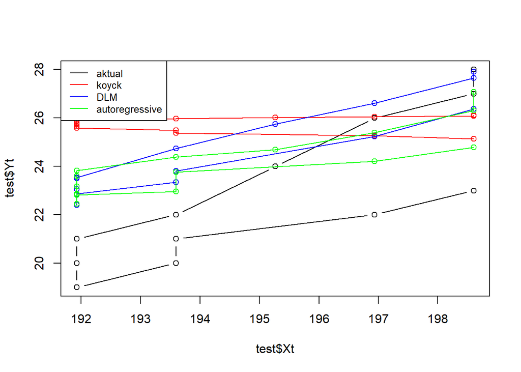

```r
par(mfrow=c(1,1))
plot(test$Xt, test$Yt, type="b", col="black")
points(test$Xt, fore.koyck$forecasts,col="red")
lines(test$Xt, fore.koyck$forecasts,col="red")
points(test$Xt, fore.dlm$forecasts,col="blue")
lines(test$Xt, fore.dlm$forecasts,col="blue")
points(test$Xt, fore.ardl$forecasts,col="green")
lines(test$Xt, fore.ardl$forecasts,col="green")
legend("topleft",c("aktual", "koyck","DLM", "autoregressive"), lty=1, col=c("black","red","blue","green"), cex=0.8)
```

Berdasarkan plot tersebut, terlihat bahwa plot yang paling mendekati data aktualnya adalah Model autoregressive, sehingga dapat disimpulkan model terbaik dalam hal ini adalah model autoregressive.